# 第 12 章 投资组合回测

本节介绍分析和比较投资策略时会使用的记号与框架。组合回测常被构想和理解为寻找最佳策略，或至少寻找一个稳定盈利策略的过程。如果执行得很彻底，这项可能漫长的工作会诱使外行把偶然好运误认为稳健策略。两篇连续发表的论文警示了**数据窥探的危险**，这与 $p$-hacking 有关。在两种情形中，研究者都会反复折磨数据，直到找到想要的结果。

Fabozzi 和 Prado（2018）指出，公开发表的通常只有看似有效的策略，而背后往往已经测试过成千上万种方案。从中挑出一个表现出众的离群值，也就是唯一看似奏效的策略，转入实际交易后很可能令人失望。类似地，R. Arnott、Harvey 和 Markowitz（2019）提出了一系列原则和防护措施，供分析师在策略回测中遵循，以避免各类错误。最严重的错误之一是**假阳性**：研究者通过选择性报告，发现某个策略只在极为特定的设定下跑赢，而一旦投入实际交易便很可能失效。

除了关于组合构建的这些建议，R. Arnott 等（2019）还警告，不要盲目投资与学术因子相关的智能贝塔产品。直白地说，预期不应设得太高，否则会面临失望风险。他们文章的另一个要点是，**经济周期**对因子收益有很强影响：相关性会快速变化，重大下行期的回撤可能被放大。

回测比看起来更复杂，很容易犯一些小错误，从而得到*表面上*不错的组合策略。本章给出执行这一工作的严谨方法，讨论若干注意事项，并提供一个较长示例。

## 12.1 设定流程

我们考虑一个具有三个维度的数据集：时间 $t=1,\dots,T$、资产 $n=1,\dots,N$ 和特征 $k=1,\dots,K$。这些属性之一必须是资产 $n$ 在时间 $t$ 的价格，记为 $p_{t,n}$。由此，算术收益的计算很直接（$r_{t,n}=p_{t,n}/p_{t-1,n}-1$），任何启发式盈利性度量也同样直接。为简单起见，我们假设时间点等距或均匀，即 $t$ 可以是交易日或月份的索引。如果每个时间点 $t$ 上所有资产都有可用数据，那么数据集包含 $I=T\times N$ 行。

数据集首先分为样本外期和**初始缓冲期**。初始缓冲期为第一次构建组合所需的模型提供训练数据，其长度由训练样本窗口决定。窗口有两种设置：固定长度（通常为 2 至 10 年）或逐步扩展。采用固定窗口时，训练样本随时间滚动，只保留最近的数据；采用扩展窗口时，模型使用截至当时的全部可用数据，样本规模随时间增加。后一种做法可能产生问题，因为回测早期可用的信息远少于后期。此外，是否应纳入完整的收益与特征历史仍有争议。支持者认为，这能让模型经历多种**市场环境**；反对者则认为，旧数据已经过时，不仅用处有限，还可能误导模型，因为它无法反映当前或未来的短期波动。

因此，训练样本采用滚动期间选项，如图 12.1 所示。

[figure not shown]

图 12.1：使用滚动窗口进行回测。第一期的训练集就是初始缓冲期。

两个关键设计选择是**再平衡频率**和标签对应的**预测期**。二者不必相同，但必须相互协调。用未来 12 个月收益率作为标签以捕捉较长期趋势，再按月或按季度调整持仓，可能是合理的；反过来，用月度收益率训练短期信号，却按较长期限持有而不调整，就不太一致。

这些选择会直接影响回测的执行方式。如果记：

- $\Delta_h$ 表示两次再平衡日期之间的持有期（以天或月计）；
- $\Delta_s$ 表示所需训练窗口的长度（以天或月计，不考虑横截面上的资产数量）；
- $\Delta_l$ 表示计算标签所覆盖的预测期（以天或月计），

那么训练样本的总长度应为 $\Delta_s+\Delta_l$。事实上，在任意时点 $t$，训练样本都应止于 $t-\Delta_l$，这样最后一个点对应的标签才是计算到时间 $t$ 为止的。图 12.2 用红色危险区强调了这一点。我们称其为红区，是因为任何时间索引 $s$ 落在区间 $(t-\Delta_l,t]$ 内的观测都会产生前视偏差。事实上，如果某个特征的索引为 $s \in (t-\Delta_l,t]$，则按定义，标签覆盖区间 $[s,s+\Delta_l]$，且 $s+\Delta_l>t$。在时间 $t$，这需要知道未来信息，自然并不现实。

[figure not shown]

图 12.2：滚动训练样本中的细节。

## 12.2 将信号转化为投资组合权重

第 5 章到第 11 章介绍的预测工具首先产生一个信号，该信号应当包含有关资产未来收益率的信息。这个信号可以通过多种方式转化为投资决策；关于如何把机器学习工具纳入这一过程，可参阅 Snow（2020）。

组合构建至少包含两个步骤，信号可以用于其中任一步。如果两个步骤都依赖信号，预测结果就会对最终组合产生很大影响，因此只有在对预测具有较高置信度时才应这样做。

第一步是**资产选择**。即使模型能为大量资产生成预测，也没有必要持有全部资产。对于只做多的投资组合，利用信号剔除预计未来表现较差的资产尤其合理。许多投资策略会预先规定持仓数量，因此最直接的做法是保留预测最有利的资产、舍弃其余资产。资产定价研究经常使用这种简单方法：按某项基础特征的分位数组建**排序投资组合**；如果不同分位数组合的收益表现明显不同，例如高分位数组合平均收益率较高、低分位数组合较低，就说明该特征可能具有定价信息。

这种排序也是检验信号有效性的一种简便方法。若按照信号排名构造 $Q$ 个组合 $q=1,\dots,Q$，那么组合的样本外表现理应随 $q$ 呈单调变化。严格的单调性检验需要同时考察全部组合（例如 Romano 和 Wolf（2013）），实践中则常只比较两个极端组合。如果第 1 组与第 $Q$ 组的收益差异显著，说明信号具有价值。若允许卖空，以相等名义金额做多一个极端组合并做空另一个极端组合，便可构造美元中性的多空策略。

第二步是**加权**。如果筛选过程已经依赖信号，那么简单加权方案通常是好主意。等权组合以难以击败而闻名（见 DeMiguel、Garlappi 和 Uppal（2009）），尤其是与市值加权替代方案相比，如 Plyakha、Uppal 和 Vilkov（2016）所示。更高级的方案包括等风险贡献（Maillard、Roncalli 和 Teiletche（2010））和有约束最小方差（Coqueret（2015））。二者都只依赖资产协方差矩阵，而不依赖预期收益向量的任何代理。

为完整起见，我们明确写出 Coqueret（2015）的一个推广，它是一个通用的有约束二次规划：

\begin{equation} \tag{12.1} \underset{\textbf{w}}{\text{min}} \ \frac{\lambda}{2} \textbf{w}'\boldsymbol{\Sigma}\textbf{w}-\textbf{w}'\boldsymbol{\mu} , \quad \text{s.t.} \quad \begin{array}{ll} \textbf{w}'\textbf{1}=1, \\ (\textbf{w}-\textbf{w}_-)'\boldsymbol{\Lambda}(\textbf{w}-\textbf{w}_-) \le \delta_R,\\ \textbf{w}'\textbf{w} \le \delta_D, \end{array} \end{equation}

左侧是常见的**均值-方差优化**目标，右侧施加了三个约束。23 第一个是预算约束，即权重之和为一。第二个约束通过对角矩阵 $\Lambda$ 惩罚权重相对当前配置 $\textbf{w}_-$ 的变化，以控制交易成本。这一点很重要：组合很少从零开始构建，多数时候是在现有持仓上进行**调整**。为减少交易订单及相应成本，可以惩罚相对于现有组合的大幅变动。在上述优化问题中，当前权重记为 $\textbf{w}_-$，目标权重记为 $\textbf{w}$，因此 $\textbf{w}-\textbf{w}_-$ 是目标持仓相对当前持仓的偏离向量。项 $(\textbf{w}-\textbf{w}_-)'\boldsymbol{\Lambda}(\textbf{w}-\textbf{w}_-)$ 是由对角系数 $\Lambda_{n,n}$ 加权的平方偏离之和。由于不同资产的流动性不同，交易成本也可能不同，因此这种加权很有用，例如大盘股流动性更强、交易成本通常更低。当 $\delta_R$ 减小时，目标权重相对当前持仓的偏离必须控制在由 $\delta_R$ 设定的上限内，换手率也会下降。最后一个约束通过组合的 Herfindhal-Hirschmann 指数强制**分散化**：$\delta_D$ 越小，组合越分散。

考虑投资范围内共有 $N$ 个资产，式 (12.1) 对应的拉格朗日函数为：

\begin{equation} \tag{12.2} L(\textbf{w})= \frac{\lambda}{2} \textbf{w}'\boldsymbol{\Sigma}\textbf{w}-\textbf{w}'\boldsymbol{\mu}-\eta (\textbf{w}'\textbf{1}_N-1)+\kappa_R ( (\textbf{w}-\textbf{w}_-)'\boldsymbol{\Lambda}(\textbf{w}-\textbf{w}_-) - \delta_R)+\kappa_D(\textbf{w}'\textbf{w}-\delta_D), \end{equation}

一阶条件

\begin{align} \frac{\partial}{\partial \textbf{w}}L(\textbf{w})= \lambda \boldsymbol{\Sigma}\textbf{w}-\boldsymbol{\mu}-\eta\textbf{1}_N+2\kappa_R \boldsymbol{\Lambda}(\textbf{w}-\textbf{w}_-)+2\kappa_D\textbf{w}=0, \end{align}

给出

\begin{equation} \tag{12.3} \textbf{w}^*_\kappa= (\lambda \boldsymbol{\Sigma}+2\kappa_R \boldsymbol{\Lambda} +2\kappa_D\textbf{I}_N)^{-1} \left(\boldsymbol{\mu} + \eta_{\lambda,\kappa_R,\kappa_D} \textbf{1}_N+2\kappa_R \boldsymbol{\Lambda}\textbf{w}_-\right), \end{equation}

其中

\begin{align} \eta_{\lambda,\kappa_R,\kappa_D}=\frac{1- \textbf{1}_N'(\lambda\boldsymbol{\Sigma}+2\kappa_R \boldsymbol{\Lambda}+2\kappa_D\textbf{I}_N)^{-1}(\boldsymbol{\mu}+2\kappa_R\boldsymbol{\Lambda}\textbf{w}_-)}{\textbf{1}'_N(\lambda \boldsymbol{\Sigma}+2\kappa_R \boldsymbol{\Lambda}+2\kappa_D\textbf{I}_N)^{-1}\textbf{1}_N}. \end{align}

该参数确保预算约束得到满足。式 (12.3) 中的最优权重取决于三个调节参数：$\lambda$、$\kappa_R$ 和 $\kappa_D$。

- 当 $\lambda$ 较大时，重点更多放在降低风险而非最大化利润上（鉴于风险更容易预测，这通常是个好主意）；
- 当 $\kappa_R$ 较大时，式 (12.2) 中交易成本的重要性较高，因此在 $\kappa_R \rightarrow \infty$ 的极限下，最优权重等于旧权重 $\textbf{w}_-$（其他参数取有限值时）。
- 当 $\kappa_D$ 较大时，投资组合更加分散；在其他条件相同时，当 $\kappa_D \rightarrow \infty$，各资产权重趋于相等（等于 $1/N$）。
- 当 $\kappa_R=\kappa_D=0$ 时，我们恢复经典均值-方差权重，它是最大夏普比率组合（与 $(\boldsymbol{\Sigma})^{-1} \boldsymbol{\mu}$ 成比例）和最小方差组合（与 $(\boldsymbol{\Sigma})^{-1} \textbf{1}_N$ 成比例）的混合。

这个看似复杂的公式实际上非常灵活且易于处理。在找到 $\lambda$、$kappa_R$ 和 $kappa_D$ 的现实取值之前，需要一些测试和调整（见本章末的练习）。Pedersen、Babu 和 Levine（2020）建议了类似形式，只是协方差矩阵会向样本方差对角矩阵收缩，而预期收益是信号与锚定组合的混合。作者认为，他们的一般形式与稳健优化（另见 Kim、Kim 和 Fabozzi（2014））、贝叶斯推断（Lai 等（2011））、随机矩阵理论下的矩阵去噪，以及自然地与**收缩**有关。事实上，收缩预期收益已经存在相当长时间（Jorion（1985）、Kan 和 Zhou（2007）以及 Bodnar、Parolya 和 Schmid（2013）），其目的只是分散化并降低估计风险。

## 12.3 投资组合评估指标

投资组合评估是回测中的关键阶段。本节虽不穷尽所有内容，但旨在覆盖组合评估中最重要的方面。

### 12.3.1 讨论

虽然评估机器学习工具的准确性（见第 10.1 节）当然有价值（也很必要！），但组合收益才是回测中的最终标尺。这类工作中的一个基本要素是**基准**，因为原始指标和绝对指标本身意义不大。

这不仅在组合层面成立，在机器学习引擎层面也成立。在前几章的大多数试验中，模型在测试集上的 MSE 约为 0.037。一个有意思的数字是该集合中一个月收益的方差，它对应于始终预测常数 0 所犯的误差。这个数字等于 0.037，这意味着复杂算法并没有真正优于朴素启发式方法。这一基准也是 Gu、Kelly 和 Xiu（2020b）的样本外 $R^2$ 所使用的基准。

在组合选择中，最基本的配置是均匀配置，即每个资产获得相同权重。这个看似简单的方案实际上是一个极强基准，长期持续击败它很难（见 DeMiguel、Garlappi 和 Uppal（2009）以及 Plyakha、Uppal 和 Vilkov（2016））。理论上，当不确定性、模糊性或估计风险很高时，均匀组合是最优的（Pflug、Pichler 和 Wozabal（2012），Maillet、Tokpavi 和 Vaucher（2015））；实证上，即便在因子层面也无法跑赢它（Dichtl、Drobetz 和 Wendt（2020））。下面，我们将选择所有股票的**等权**（EW）组合作为基准。

### 12.3.2 收益与风险指标

接下来定义从业者和学术界常用的指标。下文分别用 $r^P=(r_t^P)_{1\le t\le T}$ 和 $r^B=(r_t^B)_{1\le t\le T}$ 表示组合收益和基准收益。提到一般收益时，则简单写作 $r_t$。分析它们有许多方式，其中大多数依赖其分布。

最简单的指标是平均收益：

\begin{align} \bar{r}_P=\mu_P=\mathbb{E}[r^P]\approx \frac{1}{T}\sum_{t=1}^T r_t^P, \quad \bar{r}_B=\mu_B=\mathbb{E}[r^B]\approx \frac{1}{T}\sum_{t=1}^T r_t^B, \end{align}

如果 $\mathbb{E}[r^P]>\mathbb{E}[r^B]$，该组合就值得关注。上式使用算术平均，也可以改用几何平均，此时：

\begin{align} \tilde{\mu}_P\approx \left(\prod_{t=1}^T(1+r^P_t) \right)^{1/T}-1 , \quad \tilde{\mu}_B \approx \left(\prod_{t=1}^T(1+r^B_t) \right)^{1/T}-1. \end{align}

第二个定义的好处是考虑了收益复利，因此能够补偿波动泵效应。为理解这一点，考虑一个非常简单的两期模型，收益分别为 $−r$ 和 $+r$。算术平均为零，但几何平均 $\sqrt{1-r^2}-1$ 为负。

与分类任务中的准确率类似，命中率衡量仓位方向判断正确的比例，即已实现收益率为正时做多，或已实现收益率为负时做空。它可以在资产层面计算（方向正确的头寸占比24），也可以在投资组合层面计算；还可以基于绝对收益率或相对基准的收益率定义。更有意义的一种口径是策略跑赢基准的期数占比。但命中率本身并不充分，因为许多次小幅盈利仍可能被少数几次巨额亏损抵消。

最后，一个重要的说明。在本书所有监督学习工具示例中，我们都把命中率与 0.5 比较。这实际上是错误的，因为如果投资者看多，他或她可以始终押注上涨。在这种情况下，命中率就是收益为正的时间比例。长期来看，该概率高于 0.5。在我们的样本中，它等于 0.556，明显高于 0.5。这可以被视为一个需要超越的基准。

收益指标几乎总是伴随**风险度量**。收益的二阶矩通常用于量化组合波动幅度。较大方差意味着收益、进而组合价值会有较大波动。这就是为什么收益标准差被称为组合波动率。

\begin{align} \sigma^2_P=\mathbb{V}[r^P]\approx \frac{1}{T-1}\sum_{t=1}^T (r_t^P-\mu_P)^2, \quad \sigma^2_B=\mathbb{V}[r^B]\approx \frac{1}{T-1}\sum_{t=1}^T (r_t^B-\mu_B)^2. \end{align}

在这种情况下，如果组合相对于基准风险更低，即 $\sigma_P^2<\sigma_B^2$，且平均收益相等（或可比），则可以偏好该组合。

收益的高阶矩有时也会使用（偏度和峰度），但远不如前述指标常见。例如 Harvey 等（2010）提供了一种在组合构建过程中纳入它们的方法。

对某些人而言，波动率是不完整的风险度量。可以认为，它应分解为“好”波动率（价格上涨时）与价格下跌时的“坏”波动率。下行半方差计算的是负收益上的方差：

\begin{align} \sigma^2_-\approx \frac{1}{\text{card}(r_t<0)}\sum_{t=1}^T (r_t-\mu_P)^21_{\{r_t<0\}}. \end{align}

平均收益和波动率是从业者常用的矩指标。另一些指标关注收益分布的其他方面，尤其是尾部和极端事件。**风险价值**（VaR）就是一例。如果 $F_r$ 是收益的经验累积分布函数（CDF），置信水平 $\alpha$（通常取 95%）下的 VaR 为

\begin{align} \text{VaR}_\alpha(\textbf{r}_t)=F_r(1-\alpha). \end{align}

它给出一个不利收益阈值：平均而言，收益落到该阈值以下的概率为 $(1-\alpha)$%。更保守的度量是条件风险价值（CVaR），也称为预期损失，它计算最差 $(1-\alpha)$% 情景下的平均损失。其经验估计为

\begin{align} \text{CVaR}_\alpha(\textbf{r}_t)=\frac{1}{\text{Card}(r_t < \text{VaR}_\alpha(\text{r}_t))}\sum_{r_t < \text{VaR}_\alpha(\text{r}_t)}r_t. \end{align}

进一步考察更严重的风险时，衡量损失的极端指标是**最大回撤**，即策略价值从峰值回落的最大幅度。如果用 $P_t$ 表示组合在时间 $t$ 的价值，则回撤为

\begin{align} D_T^P=\underset{0 \le t \le T}{\text{max}} P_t-P_T , \end{align}

最大回撤则为

\begin{align} MD_T^P=\underset{0 \le s \le T}{\text{max}} \left(\underset{0 \le t \le s}{\text{max}} P_t-P_s, 0\right) . \end{align}

### 12.3.3 基于因子的评估

按照因子模型的思路，也可以从因子暴露的角度评估投资表现。式 (3.1) 的原始形式为：

\begin{align} r_{t,n}= \alpha_n+\sum_{k=1}^K\beta_{t,k,n}f_{t,k}+\epsilon_{t,n}, \end{align}

则估计得到的 $\hat{\alpha}_n$ 是无法由其他因子解释的表现。当收益为超额收益（高于无风险利率），且只有一个因子即市场因子时，该量称为 Jensen's alpha（Jensen（1968））。通常，它简称为 alpha。另一个估计值 $\hat{\beta}_{t,M,n}$（$M$ 表示市场）是市场贝塔。

随着因子投资兴起，报告包含更多因子的回归 alpha 也成为惯例。加入规模与价值溢价（如 Fama 和 French（1993）），甚至加入动量因子（Carhart（1997）），有助于判断策略是否创造了超出常见因子溢价的增量价值。

### 12.3.4 风险调整度量

自 Markowitz（1952）以来，平均收益与波动率之间的权衡就是现代金融的基石。综合这两个指标最简单的方式是使用**信息比率**：

\begin{align} IR(P,B)=\frac{\mu_{P-B}}{\sigma_{P-B}}, \end{align}

其中下标 $P-B$ 表示均值和标准差是在收益为 $r_t^P-r_t^B$ 的多空组合上计算的。分母 $\sigma_{P-B}$ 有时称为**跟踪误差**。

最广泛使用的信息比率是**夏普比率**（Sharpe（1966）），此时基准是某种无风险资产。与其直接计算两个组合或策略之间的信息比率，人们通常比较它们的夏普比率。简单比较可以借助统计检验（见例如 Ledoit 和 Wolf（2008））。

更极端的风险度量也可以作为风险调整指标的分母。例如，Managed Account Report（MAR）比率计算为

\begin{align} MAR^P = \frac{\tilde{\mu}_P}{MD^P}, \end{align}

而 Treynor 比率等于

\begin{align} \text{Treynor}=\frac{\mu_P}{\hat{\beta}_M}, \end{align}

即（超额）收益除以市场贝塔（见 Treynor（1965））。Hübner（2005）将这一定义推广到多因子暴露，形成广义 Treynor 比率：

\begin{align} \text{GT}=\mu_P\frac{\sum_{k=1}^K\bar{f}_k}{\sum_{k=1}^K\hat{\beta}_k\bar{f}_k}, \end{align}

其中 $\bar{f}_k$ 是因子 $f_{t,k}$ 的样本平均。关于该比率解析性质的详细说明，请参阅原文。

### 12.3.5 交易成本与换手率

调整组合持仓会产生成本。一般而言，时间 $t$ 的一次再平衡总成本与 $C_t=\sum_{n=1}^N | \Delta w_{t,n}|c_{t,n}$ 成比例，其中 $\Delta w_{t,n}$ 是资产 $n$ 的持仓变化，$c_{t,n}$ 是相应的单位交易成本。后者通常难以预测，因此实践中常用代理变量估计，例如市值（大盘股流动性更强，交易成本通常更低）或买卖价差（价差越小，交易成本越低）。

作为一阶近似，计算平均换手率通常很有用：

\begin{align} \text{Turnover}=\frac{1}{T-1}\sum_{t=2}^T\sum_{n=1}^N|w_{t,n}-w_{t-,n}|, \end{align}

其中 $w_{t,n}$ 是时间 $t$ 再平衡后的目标权重，$w_{t-,n}$ 是再平衡前、经上一持有期已实现收益率漂移后的实际权重。按惯例，初始建仓不纳入平均换手率。交易成本可以近似为换手率乘以资产横截面上的平均或中位单位交易成本。这只是已实现成本的一阶估计，没有考虑投资组合规模随时间的变化；即便如此，粗略估计也远好于完全忽略成本。

一旦交易成本（TC）年化，就可以从平均收益中扣除，以得到更现实的盈利性图景。同样，组合 $P$ 经交易成本调整后的夏普比率为

\begin{equation} \tag{12.4} SR_{TC}=\frac{\mu_P-TC}{\sigma_P}. \end{equation}

学术研究经常忽略交易成本，但在实际交易中，交易成本可能产生相当大的影响（例如见 Novy-Marx 和 Velikov（2015））。DeMiguel 等（2020）说明了如何利用因子投资及因子暴露合并、对冲持仓，从而降低总体成本。

## 12.4 常见错误与问题

## 12.4.1 前视数据

投资组合回测中最常见的错误之一，是使用决策时尚不可得的前视数据。例如，若把图 12.2 所示危险区内的样本纳入训练，时间 $t$ 使用的标签就会依赖 $t+1$、$t+2$ 等未来时点的信息。应逐步检查代码，确保每次决策只使用当时已经公布且实际可得的数据，避免产生前视偏差。

## 12.4.2 回测过拟合

第二个主要问题是回测过拟合。它与训练集过拟合的类比很容易理解。这是一个众所周知的问题，例如 White（2000）以及 Romano 和 Wolf（2005）对其进行了形式化。在组合选择中，可参见 Bajgrowicz 和 Scaillet（2012）、Bailey 和 Prado（2014）、Lopez de Prado 和 Bailey（2020）及其中参考文献。

在任意给定时点，回测只依赖于一个特定数据集。第一次回测的结果往往并不令人满意，原因可能有很多。因此，人们很容易想再试一次，调整一些可能并非最优的参数。第二次测试可能更好，但还不够好。于是第三次尝试中，可以测试新的加权方案，并搭配一个新的（更复杂的）预测引擎。通过迭代，回测者最终总能得到一个表现足够好的策略，这只是时间和试验次数问题。

回测过拟合意味着，不能指望实盘夏普比率达到回测水平。审慎的从业者通常至少把回测夏普比率打五折（Harvey 和 Liu（2015），Suhonen、Lennkh 和 Perez（2017））。Bailey 和 Prado（2014）进一步提出了对非正态收益和多次策略试验进行校正的去膨胀夏普比率（Deflated Sharpe Ratio）检验，前提是保留所有已测试策略的相关指标。其统计量为：

\begin{equation} \tag{12.5} t = \phi\left((SR-SR^*)\sqrt{\frac{T-1}{1-\gamma_3SR+\frac{\gamma_4-1}{4}SR^2}} \right), \end{equation}

其中 $SR$ 是所有被测试策略中最佳策略获得的夏普比率，并且

\begin{align} SR^*=\mathbb{E}[SR]+\sqrt{\mathbb{V}[SR]}\left((1-\gamma)\phi^{-1}\left(1-\frac{1}{N}\right)+\gamma \phi^{-1}\left(1-\frac{1}{Ne}\right) \right), \end{align}

是理论平均最大 SR。此外，

- $T$ 是交易日期数量；
- $\gamma_3$ 和 $\gamma_4$ 是所选（最佳）策略收益的偏度（$skewness$）和峰度（$kurtosis$）；
- $\phi$ 是标准高斯分布的累积分布函数，$\gamma\approx 0,577$ 是 Euler-Mascheroni 常数；
- $N$ 表示策略试验数量。

如果上面定义的 $t$ 低于某个阈值（例如 0.95），就不能认为 $SR$ 在全部已测试策略中具有显著性。遗憾的是，多数情况下正是如此。在式 (12.5) 中，观测到的 SR 必须高于理论平均最大值 $SR^∗$，而且缩放因子必须足够大，使 $\phi$ 的自变量足够接近 2，从而让 $t$ 超过 0.95。

在科学研究中，这类测试过拟合也称为 p 值操纵。它在金融经济学中相当常见，强烈建议阅读 Harvey（2017）以了解这一现象的规模。凡是广泛使用统计检验的领域，都可能出现 p 值操纵（例如见 Head 等（2015））。应对方法包括：

1. 不要把决策完全建立在 p 值上（Amrhein、Greenland 和 McShane（2019））；
2. 使用检测工具（Elliott、Kudrin 和 Wuthrich（2019））；
3. 使用能够同时处理多组统计量的高级方法，例如 Harvey（2017）提出的贝叶斯化 p 值方法，将先验判断纳入分析；也可以采用 Romano 和 Wolf（2005）以及 Simonsohn、Nelson 和 Simmons（2014）提出的其他检验。

第一种做法较为审慎，但缺点是仍需另选一个带有任意性的决策标准。

### 基本防护措施

正如本章开头所提到的，关于回测的两篇常识性参考是 Fabozzi 和 Prado（2018）以及 R. Arnott、Harvey 和 Markowitz（2019）。这两篇文章给出的建议通常都审慎且周到。

还需要注意回测的输出。式 (12.4) 定义的交易成本调整后夏普比率是一项简单、直观且应用广泛的指标。记基准的相应数值为 $SR_{TC}^B$，并将基准设为可投资范围内全部资产的等权组合（在本书数据集中约为一千只美国股票）。如果最佳策略的 $SR_{TC}^P$ 高于 $2\times SR_{TC}^B$，回测过程很可能存在问题。

该准则基于两个假设：

1. 样本外期间足够长；
2. 以及多头组合。

任何实际可行的策略都不太可能长期大幅跑赢稳健基准。在波动率相近的情况下，年化收益比基准高 150 个基点已经是很大的成就。如果回测收益比基准高出 5% 以上，就应当仔细排查。

## 12.5 非平稳性的含义：预测很难

本小节分为两部分：第一部分讨论使预测如此困难的原因；第二部分介绍一个重要理论结果，它最初面向机器学习提出，但能启发任何面对样本外测试的学科。与这一主题相关的一个有趣贡献是 Farmer、Schmidt 和 Timmermann（2019）的研究。作者评估了线性模型随时间变化的预测拟合：他们显示拟合强烈变化，有时模型表现很好，有时则不那么好。没有理由认为机器学习算法不会如此。

### 12.5.1 一般评论

细心读者应该已经注意到，在第 5 章到第 11 章中，机器学习引擎的表现并不出色。这些令人失望的结果是有意保留的，用来强调一个关键事实：机器学习不是万能药，也不是能把数据变成黄金预测的魔法。大多数基于机器学习的预测都会失败。事实上，这不仅适用于非常先进和复杂的技术，也适用于更简单的计量经济学方法（Dichtl 等（2020）），这再次强调了复现结果、挑战其有效性的必要性。

原因之一是数据集充满噪声，提取哪怕最微小的信号都是艰巨挑战（关于这一主题的更多细节，建议仔细阅读 Timmermann（2018）的引言）。这一点的一个理由是，股票领域中的因子分析具有不断随时间变化的性质。一些因子可能某一年表现很好，下一年表现很差；在完全自动化、基于数据的配置过程中，这些反转可能代价高昂。

事实上，这正是机器学习取得巨大进展的许多领域与金融之间的主要差异。在图像识别中，数字总会具有相同形状，猫、公交车等也是如此。同样，动词总会是动词，语言中的句法也不会改变。这种不变性虽然有时难以把握，25 但却是计算机视觉和自然语言处理取得巨大改进的关键。

在因子投资中，似乎不存在这种不变性（见 Cornell（2020））。没有任何因子，也没有任何（可能非线性的）因子组合，能够在几十年的长时期内解释并准确预测收益。26 学术文献尚未找到这样的模型；但即使找到了，一个简单的套利推理也会在未来数据集中逻辑上使其结论失效。

### 12.5.2 没有免费午餐定理

首先要强调，机器学习中的没有免费午餐定理与同名的资产定价条件无关（见例如 Delbaen 和 Schachermayer（1994），或更新的 Cuchiero、Klein 和 Teichmann（2016））。最初表述由 Wolpert（1992a）给出，但我们也建议读者参阅较新的 Ho 和 Pepyne（2002）。事实上有若干定理，其中两个可见 Wolpert 和 Macready（1997）。

该定理的表述很抽象，需要先约定一些记号。假设对任意训练样本 $S=(\{\textbf{x}_1,y_1\}, \dots, \{\textbf{x}_I,y_I\})$，都存在一个 oracle（理想）函数 $f$，能把特征完美映射到标签：$y_i=f(\textbf{x}_i)$。函数 $f$ 属于一个非常大的函数集合 $F$。再用 $\mathcal{H}$ 表示预测者用来近似 $\mathcal{F}$ 的候选函数集合。例如，$\mathcal{H}$ 可以是前馈神经网络空间、决策树空间，或两者的并集。$\mathcal{H}$ 中的元素记为 $h$，$\mathbb{P}[h|S]$ 表示给定样本 $S$ 时 $h$ 的分布，这一分布在很大程度上是未知的。类似地，$\mathbb{P}[f|S]$ 表示给定 $S$ 时 oracle 函数的分布。最后，假设特征服从给定分布 $\mathbb{P}[\textbf{x}]$。

现在考虑两个模型 $h_1$ 和 $h_2$。该定理通常针对分类任务表述。在给定 $S$ 的条件下，选择 $h_k$ 后在训练样本 $S$ 之外产生的误差可量化为

\begin{equation} \tag{12.6} E_k(S)= \int_{f,h}\int_{\textbf{x}\notin S} \underbrace{ (1-\delta(f(\textbf{x}),h_k(\textbf{x})))}_{\text{error term}} \underbrace{\mathbb{P}[f|S]\mathbb{P}[h|S]\mathbb{P}[\textbf{x}]}_{\text{distributional terms}}, \end{equation}

其中 $\delta(\cdot,\cdot)$ 是 Kronecker delta 函数：

\begin{equation} \tag{12.7} \delta(x,y)=\left\{\begin{array}{ll} 0 & \text{if } x\neq y \\ 1 & \text{if } x = y \end{array} .\right. \end{equation}

没有免费午餐定理之一指出 $E_1(S)=E_2(S)$。也就是说，仅凭对 $S$ 的了解，平均而言不存在始终更优的算法。要构建表现良好的算法，分析师或计量经济学家必须对 $y$ 与 $\textbf{x}$ 之间的关系结构作出先验判断，并把这些判断融入模型。若先验判断错误，得到的模型也可能表现不佳。

## 12.6 第一个示例：完整回测

最后，我们完整展示一个机器学习策略的严谨回测实现。下面的内容是第 5.2.2 节的扩展。沿用相同思路，我们把回测分为四部分：

1. 变量的创建/初始化；
2. 在一个主函数中定义策略；
3. 回测循环本身；
4. 评估指标。

因此，我们从初始化开始。

```python
import xgboost as xgb
import datetime as dt
from datetime import datetime

sep_oos= "2007-01-01"                                          # Starting point for backtest
ticks= list(data_ml['stock_id'].unique())                      # List of all asset ids
N= len(ticks)                                                  # Max number of assets
t_oos= list(returns.index[returns.index>sep_oos].values)       # Out-of-sample dates
t_as= list(returns.index.values)                               # Out-of-sample dates
Tt= len(t_oos)                                                 # Nb of dates
nb_port = 2                                                    # Nb of portfolios/strategies
portf_weights= np.zeros(shape=(Tt, nb_port, max(ticks)+1))     # Initialize portfolio weights
portf_returns= np.zeros(shape=(Tt, nb_port))                   # Initialize portfolio returns
```

第一步至关重要，它为回测主体奠定基础。我们只考虑两个策略：机器学习策略和 EW（1/N）基准。主加权函数包含这两个组件，其中较复杂的机器学习策略单独定义在一个封装函数中。机器学习权重来自 XGBoost 预测；模型包含 80 棵树，学习率为 0.3，最大树深为 4，因此具备一定复杂度，但不过分复杂。得到预测后，加权方案很简单：选取预测值高于中位数的一半股票，构建等权组合。

下面的函数把所有参数都写死在代码中，例如学习率 eta 和树的数量 nrounds；也可以很容易地把它们连同数据输入一起设为函数参数。一个重要细节是，与本书其他部分不同，这里的标签是未来 12 个月收益率，原因见第 4.6 节。为加快计算，我们还按照 Coqueret 和 Guida（2020）的建议，移除标签分布的中间 60%，只保留顶部 20% 和底部 20%。这些筛选阈值同样可以作为参数传入。

```python
def weights_xgb(train_data, test_data, features):
    train_features= train_data[features]                                                                    # Indep. variable
    train_label= train_data['R12M_Usd']/ np.exp(train_data['Vol1Y_Usd'])                                    # Dep. variable ##T##
    ind = (train_label < np.quantile(train_label, 0.2))|(train_label > np.quantile(train_label, 0.8))       # Filter
    train_features= train_features.loc[ind]                                                                 # Filtered features
    train_label= train_label.loc[ind]                                                                       # Filtered label
    train_matrix=xgb.DMatrix(train_features, label=train_label)                                             # XGB format!
    params={'eta' : 0.3,                                                                                    # Learning rate
      'objective' : "reg:squarederror",                                                                     # Objective function
      'max_depth' : 4}                                                                                      # Maximum depth of trees
    fit_xgb =xgb.train(params, train_matrix,num_boost_round=80)                                             # Number of trees used
    test_features=test_data[features]                                                                       # Test sample => XGB format
    test_matrix=xgb.DMatrix(test_features)                                                                  # XGB format!
    pred = fit_xgb.predict(test_matrix)                                                                     # Single prediction
    w_names=test_data["stock_id"]                                                                           # Stocks' list
    w = pred > np.median(pred)                                                                              # Keep only the 50% best predictions
    w = w / np.sum(w)                                                                                       # Best predictions, equally-weighted
    return w, w_names
```

与第 6.4.6 节的设定相比，这里的标签不仅基于**长期**收益，还加入了波动率成分。标签的分母是波动率分位数的指数函数值，因此可以将其理解为受夏普比率启发的指标：模型试图解释和预测风险调整后收益，而非原始收益。低波动股票的收益在标签中基本不变，高波动股票的收益则会除以一个接近 3 的因子（exp(1)=2.718）。

随后，该函数被嵌入全局加权函数，后者只包装两个方案：EW 基准和基于机器学习的策略。

```python
def portf_compo(train_data, test_data, features, j):
    if j == 0:                                                                       # This is the benchmark
        N = len(test_data["stock_id"])                                               # Test data dictates allocation
        w = np.repeat(1/N,N)                                                         # EW portfolio
        w_names=test_data["stock_id"]                                                # Asset names
        return w, w_names
    elif j == 1:                                                                     # This is the ML strategy.
        return weights_xgb(train_data, test_data, features)
```

定义好该函数后，就可以进入回测主循环。由于使用的是大规模模型，循环耗时较长，在 CPU 较慢的机器上可能需要数小时。函数式编程有助于加快这一过程（见本章末练习）。此外，简单的等权基准组合只需使用 tidyverse 函数即可实现。

```python
m_offset = 12                                                                       # Offset in months for buffer period(label)
train_size = 5                                                                      # Size of training set in years
for t in range(len(t_oos)-1):                                                       # Stop before last date: no fwd ret.!
    print(t_oos[t])                                                                 # Just checking the date status
    ind= (data_ml['date'] < datetime.strftime(datetime.strptime(t_oos[t], "%Y-%m-%d")-dt.timedelta(m_offset*30), "%Y-%m-%d")) & (
        data_ml['date'] > datetime.strftime(datetime.strptime(t_oos[t], "%Y-%m-%d")-dt.timedelta(m_offset*30)-dt.timedelta(365 * train_size), "%Y-%m-%d"))
    train_data= data_ml.loc[ind,:]                                                 # Train sample
    test_data= data_ml.loc[data_ml['date'] == t_oos[t],:]                          # Test sample
    realized_returns= test_data["R1M_Usd"]                                         # Computing returns via: 1M holding period!
    for j in range(nb_port):
        temp_weights, stocks = portf_compo(train_data, test_data, features, j)      # Weights
        portf_weights[t,j,stocks] = temp_weights                                    # Allocate weights
        portf_returns[t,j] = np.sum(temp_weights * realized_returns)                # Compute returns
```

上述代码有两点需要说明。第一点涉及开头定义的两个参数：训练样本长度（5 年）和图 12.2 所示的缓冲期长度。由于标签基于长期（12 个月）收益，**缓冲期不可或缺**；只有保留这段时间间隔，才能避免回测中的前视偏差。

下面，我们创建一个计算换手率（权重变化）的函数。它既需要权重值，也需要所有资产的收益，因为再平衡之前的权重取决于上一期分配的权重，也取决于持有期内资产收益对这些原始权重的改变。

```python
def turnover(weights, asset_returns, t_oos):
    turn = 0
    for t in range(1, len(t_oos)):
        realised_returns = asset_returns[returns.index == t_oos[t]].values
        prior_weights = weights[t-1] * (1+realised_returns)                         # Before rebalancing
        turn =turn + np.sum(np.abs(weights[t] - prior_weights/np.sum(prior_weights)))
    return turn/(len(t_oos)-1)
```

定义换手率后，我们把它嵌入一个计算若干关键指标的函数中。

```python
def perf_met(portf_returns, weights, asset_returns, t_oos):
    avg_ret = np.nanmean(portf_returns)                                             # Arithmetic mean
    vol = np.nanstd(portf_returns, ddof=1)                                          # Volatility
    Sharpe_ratio = avg_ret / vol                                                    # Sharpe ratio
    VaR_5 = np.quantile(portf_returns, 0.05)                                        # Value-at-risk
    turn = turnover(weights, asset_returns, t_oos)                                  # using the turnover function
    met = [avg_ret, vol, Sharpe_ratio, VaR_5, turn]                                 # Aggregation of all of this
    return met
```

最后，我们构建一个在不同策略上循环的函数。

```python
def perf_met_multi(portf_returns, weights, asset_returns, t_oos, strat_name):
    J = weights.shape[1]                                                            # Number of strategies
    met = []                                                                        # Initialization of metrics
    for j in range(J):                                                              # One slighlty less ugly loop
        temp_met = perf_met(portf_returns[:,j], weights[:,j,:], asset_returns, t_oos)
        met.append(temp_met)
    return pd.DataFrame(met, index=strat_name, columns = ['avg_ret', 'vol', 'Sharpe_ratio', 'VaR_5', 'turn']) # Stores the name of the strat
```

给定组合权重和收益后，剩下的就是计算资产收益，并将它们输入汇总指标函数。

```python
asset_returns = data_ml[['date', 'stock_id', 'R1M_Usd']].pivot(index='date', columns='stock_id',values='R1M_Usd')
na = list(set(np.arange(max(asset_returns.columns)+1)).difference(set(asset_returns.columns)))          # find the missing stock_id
asset_returns[na]=0                                                                                     # Adding into asset return dataframe
asset_returns = asset_returns.loc[:,sorted(asset_returns.columns)]
asset_returns.fillna(0, inplace=True)                                                                   # Zero returns for missing points
perf_met_multi(portf_returns, portf_weights, asset_returns, t_oos,strat_name = ["EW", "XGB_SR"])
```

|  | avg_ret | vol | Sharpe_ratio | VaR_5 | turn |
| --- | --- | --- | --- | --- | --- |
| EW | 0.009697 | 0.056429 | 0.171848 | -0.077125 | 0.071451 |
| XGB_SR | 0.012603 | 0.063768 | 0.197635 | -0.083359 | 0.567993 |

最后，人们总是忍不住绘制相应组合价值，我们在图 12.3 中展示两张相关图。

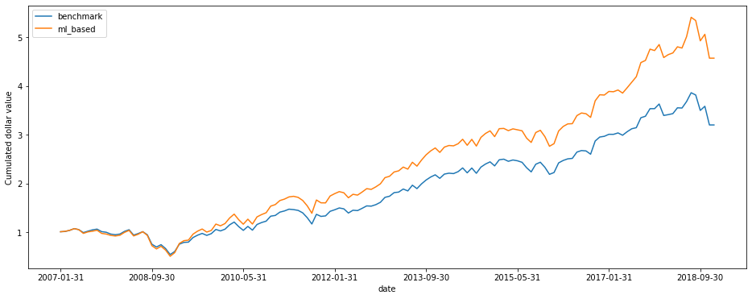

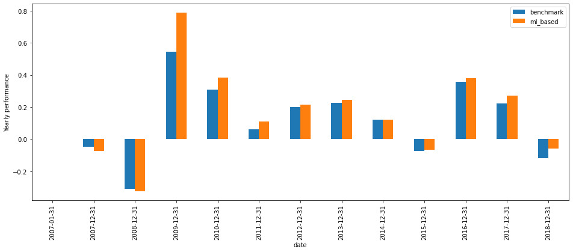

```python
g1 = pd.DataFrame([t_oos, np.cumprod(1+portf_returns[:,0]), np.cumprod(1+portf_returns[:,1])],index = ["date","benchmark","ml_based"]).T # Creating cumulated timeseries
g1.reset_index(inplace=True)                                                                                                             # Data wrangling
g1['date_month']=pd.to_datetime(g1['date']).dt.month                    # Creating a new column to select dataframe partition for secong plot (yearly performance)
g1.set_index('date',inplace=True)                                       # Setting date index for plots
g2=g1[g1['date_month']==12]                                             # Selecting pseudo end of year NAV
g2=g2.append(g1.iloc[[0]])                                              # Adding the first date of Jan 2007
g2.sort_index(inplace=True)                                             # Sorting dates
g1[["benchmark","ml_based"]].plot(figsize=[16,6],ylabel='Cumulated dollar value')                                                        # plot evidently!
g2[["benchmark","ml_based"]].pct_change(1).plot.bar(figsize=[16,6],ylabel='Yearly performance')                                          # plot evidently!
```

图 12.3：组合表现的图形展示。

在 12 年回测期中，复杂策略有 10 年跑赢基准。在四个整体亏损年份中，它在 2015 年和 2018 年的跌幅也更小。考虑到 EW 基准本就很难击败，这一改善令人满意。

## 12.7 第二个示例：回测过拟合

为结束本章，我们量化第 12.4.2 节的概念。首先，构建一个函数，用于为可批量评估的简单策略生成策略评估指标。这些策略是纯因子押注，依赖三个输入：所选特征（例如市值）、阈值水平（该特征的分位数）和方向（在分布顶部或底部做多）。

```python
def strat(data, feature, thresh, direction):
    data_tmp = data[[feature, 'date', 'R1M_Usd']].copy()                        # Data for individual feature
    data_tmp['decision'] = direction*data_tmp[feature] > direction*thresh       # Investment decision as a Boolean
    data_tmp =  data_tmp.groupby('date').apply(                                 # Date-by-date  analysis
        lambda x: np.sum(x['decision']/np.sum(x['decision']) * x['R1M_Usd']))   # Asset contribution, weight * return
    avg = np.nanmean(data_tmp)                                                  # Portfolio average return
    sd = np.nanstd(data_tmp, ddof=1)                                            # Portfolio volatility non annualised
    SR = avg / sd                                                               # Portfolio sharpe ratio
    return np.around([avg, sd, SR],4)
```

然后，我们在一组三元参数上测试该函数。选择市净率（Pb）。持仓方向为正，阈值为 0.3，这意味着策略买入 Pb 值高于分布 0.3 分位数的股票。

```python
strat(data_ml, "Pb", 0.3, 1)                                                                # Large cap
```

```
array([0.0102, 0.0496, 0.2065])
```

输出保留三个数量，它们将用于计算统计量 (12.5)。现在必须为许多策略生成这些指标。我们从创建参数网格开始。

```python
import itertools
feature = ["Div_Yld", "Ebit_Bv", "Mkt_Cap_6M_Usd", "Mom_11M_Usd", "Pb", "Vol1Y_Usd"]
thresh = np.arange(0.2, 0.9, 0.1)                                                           # Threshold
direction = np.array([1,-1])                                                                # Decision direction
```

这总共形成 84 个策略。图 12.4 展示了各策略的夏普比率：上图对应做多特征分布底部的策略，下图对应做多特征分布顶部的策略。

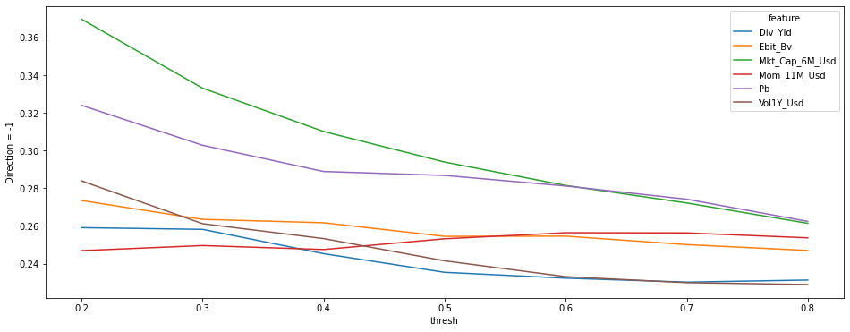

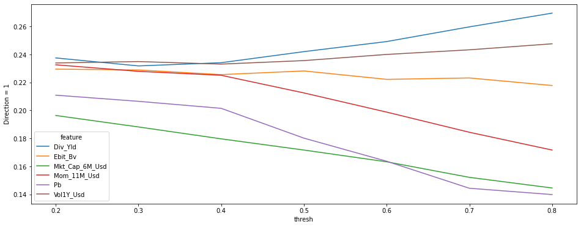

```python
grd = []                                                                 # Empty placeholder, parameters for the grid search
for f, t, d in itertools.product(feature,thresh,direction):              # Parameters for the grid search
    strat_data=[]                                                        # Empty placeholder, dataframe for the function
    strat_data=pd.DataFrame(strat(data_ml,f,t,d)).T                      # Function on which to apply the grid search
    strat_data.rename(columns={0: 'avg', 1: 'sd',2:'SR'}, inplace=True)  # Change columns names
    strat_data[['feature', 'thresh', 'direction']]=f, t, d               # Feeding parameters to construc the dataframe
    grd.append(strat_data)                                               # Appending/inserting
grd = pd.concat(grd)[['feature','thresh','direction','avg', 'sd', 'SR']] # Putting all together and reordering columns

grd[grd['direction']==-1].pivot(index='thresh',columns='feature',values='SR').plot(figsize=[16,6],ylabel='Direction = -1') # Plot!
grd[grd['direction']==1].pivot(index='thresh',columns='feature',values='SR').plot(figsize=[16,6],ylabel='Direction = 1')   # Plot!
```

图 12.4：所有回测策略的夏普比率。

最后一步是计算统计量 (12.5)。这里编写如下代码：

```python
from scipy import special as special
from scipy import stats as stats

def DSR(SR, Tt, M, g3, g4, SR_m, SR_v):                                                                         # First, we build the function
    gamma = -special.digamma(1)                                                                                 # Euler-Mascheroni constant
    SR_star = SR_m + np.sqrt(SR_v)*((1-gamma)*stats.norm.ppf(1-1/M) + gamma*stats.norm.ppf(1-1/M/np.exp(1)))    # SR*
    num = (SR-SR_star) * np.sqrt(Tt-1)                                                                          # Numerator
    den = np.sqrt(1 - g3*SR + (g4-1)/4*SR**2)                                                                   # Denominator
    return round(stats.norm.cdf(num/den),4)
```

剩下要做的是评估函数参数。“最佳”策略是图 12.4 左上角的策略，它基于市值。

```python
M = grd.shape[0]                                                                                                # Number of strategies we tested
SR = np.max(grd['SR'])                                                                                          # The SR we want to test
SR_m = np.mean(grd['SR'])                                                                                       # Average SR across all strategies
SR_v = np.var(grd['SR'], ddof=1)                                                                                # Std dev of SR
data_tmp = data_ml[['Mkt_Cap_6M_Usd', 'date', 'R1M_Usd']].copy()                                                # feature = Mkt_Cap
data_tmp.rename({'Mkt_Cap_6M_Usd':'feature'}, axis=1, inplace=True)
data_tmp['decision'] = data_tmp['feature'] < 0.2                                                                # Investment decision: 0.2 is the best threshold
returns_DSR = data_tmp.groupby('date').apply(                                                                   # Date-by-date  analysis
    lambda x:np.sum(x['decision']/np.sum(x['decision']) * x['R1M_Usd']))                                        # Asset contribution, weight * return
g3 = stats.skew(returns_DSR)                                                                                    # Function/method from Scipy.stats
g4 = stats.kurtosis(returns_DSR, fisher=False)                                                                  # Function/method from Scipy.stats
Tt = returns_DSR.shape[0]                                                                                       # Number of dates
DSR(SR, Tt, M, g3, g4, SR_m, SR_v)                                                                              # The sought value!
```

```
0.6657
```

数值 0.6657 不够高（没有达到 90% 或 95% 阈值），不足以说明该策略相对于批量测试中考虑的其他策略具有显著优势。

## 12.8 编程练习

1. 只用 tidyverse 函数编写 EW 组合收益代码（不使用循环）。
2. 编写式 (12.3) 定义的高级加权函数。
3. 在一个小型回测中测试它，并检查其对参数的敏感性。
4. 使用函数式编程软件包 purrr，避免在回测中显式编写循环。

基于 3 个完全使用 Keras 训练的神经网络构建一个集成模型。每个网络接收三分之一的预测变量，并分别输出一个二分类结果（是/否或买入/卖出）。再由上层网络汇总这 3 个输出，形成最终决策。请使用 functional API，并在测试集上评估模型表现。

### 参考文献

Amrhein, Valentin, Sander Greenland, and Blake McShane. 2019. “Scientists Rise up Against Statistical Significance.” Nature 567: 305–7.

Arnott, Rob, Campbell R Harvey, Vitali Kalesnik, and Juhani Linnainmaa. 2019. “Alice’s Adventures in Factorland: Three Blunders That Plague Factor Investing.” Journal of Portfolio Management 45 (4): 18–36.

Arnott, Rob, Campbell R Harvey, and Harry Markowitz. 2019. “A Backtesting Protocol in the Era of Machine Learning.” Journal of Financial Data Science 1 (1): 64–74.

Bailey, David H, and Marcos López de Prado. 2014. “The Deflated Sharpe Ratio: Correcting for Selection Bias, Backtest Overfitting, and Non-Normality.” Journal of Portfolio Management 40 (5): 39–59.

Bajgrowicz, Pierre, and Olivier Scaillet. 2012. “Technical Trading Revisited: False Discoveries, Persistence Tests, and Transaction Costs.” Journal of Financial Economics 106 (3): 473–91.

Bodnar, Taras, Nestor Parolya, and Wolfgang Schmid. 2013. “On the Equivalence of Quadratic Optimization Problems Commonly Used in Portfolio Theory.” European Journal of Operational Research 229 (3): 637–44.

Carhart, Mark M. 1997. “On Persistence in Mutual Fund Performance.” Journal of Finance 52 (1): 57–82.

Coqueret, Guillaume. 2015. “Diversified Minimum-Variance Portfolios.” Annals of Finance 11 (2): 221–41.

Coqueret, Guillaume, and Tony Guida. 2020. “Training Trees on Tails with Applications to Portfolio Choice.” Annals of Operations Research 288: 181–221.

Cornell, Bradford. 2020. “Stock Characteristics and Stock Returns: A Skeptic’s Look at the Cross Section of Expected Returns.” Journal of Portfolio Management.

Cuchiero, Christa, Irene Klein, and Josef Teichmann. 2016. “A New Perspective on the Fundamental Theorem of Asset Pricing for Large Financial Markets.” Theory of Probability & Its Applications 60 (4): 561–79.

Delbaen, Freddy, and Walter Schachermayer. 1994. “A General Version of the Fundamental Theorem of Asset Pricing.” Mathematische Annalen 300 (1): 463–520.

DeMiguel, Victor, Lorenzo Garlappi, and Raman Uppal. 2009. “Optimal Versus Naive Diversification: How Inefficient Is the 1/N Portfolio Strategy?” Review of Financial Studies 22 (5): 1915–53.

DeMiguel, Victor, Alberto Martin Utrera, Raman Uppal, and Francisco J Nogales. 2020. “A Transaction-Cost Perspective on the Multitude of Firm Characteristics.” Review of Financial Studies 33 (5): 2180–2222.

Dichtl, Hubert, Wolfgang Drobetz, Andreas Neuhierl, and Viktoria-Sophie Wendt. 2020. “Data Snooping in Equity Premium Prediction.” Journal of Forecasting Forthcoming.

Dichtl, Hubert, Wolfgang Drobetz, and Viktoria-Sophie Wendt. 2020. “How to Build a Factor Portfolio: Does the Allocation Strategy Matter?” European Financial Management Forthcoming.

Elliott, Graham, Nikolay Kudrin, and Kaspar Wuthrich. 2019. “Detecting P-Hacking.” arXiv Preprint, no. 1906.06711.

Fabozzi, Frank J, and Marcos López de Prado. 2018. “Being Honest in Backtest Reporting: A Template for Disclosing Multiple Tests.” Journal of Portfolio Management 45 (1): 141–47.

Fama, Eugene F, and Kenneth R French. 1993. “Common Risk Factors in the Returns on Stocks and Bonds.” Journal of Financial Economics 33 (1): 3–56.

Farmer, Leland, Lawrence Schmidt, and Allan Timmermann. 2019. “Pockets of Predictability.” SSRN Working Paper 3152386.

Goto, Shingo, and Yan Xu. 2015. “Improving Mean Variance Optimization Through Sparse Hedging Restrictions.” Journal of Financial and Quantitative Analysis 50 (6): 1415–41.

Gu, Shihao, Bryan T Kelly, and Dacheng Xiu. 2020b. “Empirical Asset Pricing via Machine Learning.” Review of Financial Studies 33 (5): 2223–73.

Harvey, Campbell R. 2017. “Presidential Address: The Scientific Outlook in Financial Economics.” Journal of Finance 72 (4): 1399–1440.

Harvey, Campbell R, John C Liechty, Merrill W Liechty, and Peter Müller. 2010. “Portfolio Selection with Higher Moments.” Quantitative Finance 10 (5): 469–85.

Harvey, Campbell R, and Yan Liu. 2015. “Backtesting.” Journal of Portfolio Management 42 (1): 13–28.

Head, Megan L, Luke Holman, Rob Lanfear, Andrew T Kahn, and Michael D Jennions. 2015. “The Extent and Consequences of P-Hacking in Science.” PLoS Biology 13 (3): e1002106.

Ho, Yu-Chi, and David L Pepyne. 2002. “Simple Explanation of the No-Free-Lunch Theorem and Its Implications.” Journal of Optimization Theory and Applications 115 (3): 549–70.

Hübner, Georges. 2005. “The Generalized Treynor Ratio.” Review of Finance 9 (3): 415–35.

Jensen, Michael C. 1968. “The Performance of Mutual Funds in the Period 1945–1964.” Journal of Finance 23 (2): 389–416.

Jorion, Philippe. 1985. “International Portfolio Diversification with Estimation Risk.” Journal of Business, 259–78.

Kan, Raymond, and Guofu Zhou. 2007. “Optimal Portfolio Choice with Parameter Uncertainty.” Journal of Financial and Quantitative Analysis 42 (3): 621–56.

Kim, Woo Chang, Jang Ho Kim, and Frank J Fabozzi. 2014. “Deciphering Robust Portfolios.” Journal of Banking & Finance 45: 1–8.

Lai, Tze Leung, Haipeng Xing, Zehao Chen, and others. 2011. “Mean–Variance Portfolio Optimization When Means and Covariances Are Unknown.” Annals of Applied Statistics 5 (2A): 798–823.

Ledoit, Oliver, and Michael Wolf. 2008. “Robust Performance Hypothesis Testing with the Sharpe Ratio.” Journal of Empirical Finance 15 (5): 850–59.

Lopez de Prado, Marcos, and David H Bailey. 2020. “The False Strategy Theorem: A Financial Application of Experimental Mathematics.” American Mathematical Monthly Forthcoming.

Maillard, Sébastien, Thierry Roncalli, and Jérôme Teiletche. 2010. “The Properties of Equally Weighted Risk Contribution Portfolios.” Journal of Portfolio Management 36 (4): 60–70.

Maillet, Bertrand, Sessi Tokpavi, and Benoit Vaucher. 2015. “Global Minimum Variance Portfolio Optimisation Under Some Model Risk: A Robust Regression-Based Approach.” European Journal of Operational Research 244 (1): 289–99.

Markowitz, Harry. 1952. “Portfolio Selection.” Journal of Finance 7 (1): 77–91.

Novy-Marx, Robert, and Mihail Velikov. 2015. “A Taxonomy of Anomalies and Their Trading Costs.” Review of Financial Studies 29 (1): 104–47.

Pedersen, Lasse Heje, Abhilash Babu, and Ari Levine. 2020. “Enhanced Portfolio Optimization.” SSRN Working Paper 3530390.

Pflug, Georg Ch, Alois Pichler, and David Wozabal. 2012. “The 1/N Investment Strategy Is Optimal Under High Model Ambiguity.” Journal of Banking & Finance 36 (2): 410–17.

Plyakha, Yuliya, Raman Uppal, and Grigory Vilkov. 2016. “Equal or Value Weighting? Implications for Asset-Pricing Tests.” SSRN Working Paper 1787045.

Romano, Joseph P, and Michael Wolf. 2005. “Stepwise Multiple Testing as Formalized Data Snooping.” Econometrica 73 (4): 1237–82.

Romano, Joseph P, and Michael Wolf. 2013. “Testing for Monotonicity in Expected Asset Returns.” Journal of Empirical Finance 23: 93–116.

Sharpe, William F. 1966. “Mutual Fund Performance.” Journal of Business 39 (1): 119–38.

Simonsohn, Uri, Leif D Nelson, and Joseph P Simmons. 2014. “P-Curve: A Key to the File-Drawer.” Journal of Experimental Psychology: General 143 (2): 534.

Snow, Derek. 2020. “Machine Learning in Asset Management: Part 2: Portfolio Construction—Weight Optimization.” Journal of Financial Data Science Forthcoming.

Suhonen, Antti, Matthias Lennkh, and Fabrice Perez. 2017. “Quantifying Backtest Overfitting in Alternative Beta Strategies.” Journal of Portfolio Management 43 (2): 90–104.

Timmermann, Allan. 2018. “Forecasting Methods in Finance.” Annual Review of Financial Economics 10: 449–79.

Treynor, Jack L. 1965. “How to Rate Management of Investment Funds.” Harvard Business Review 43 (1): 63–75.

White, Halbert. 2000. “A Reality Check for Data Snooping.” Econometrica 68 (5): 1097–1126.

Wolpert, David H. 1992a. “On the Connection Between in-Sample Testing and Generalization Error.” Complex Systems 6 (1): 47.

Wolpert, David H, and William G Macready. 1997. “No Free Lunch Theorems for Optimization.” IEEE Transactions on Evolutionary Computation 1 (1): 67–82.

1. 约束往往对组合构成有有益影响，见 Jagannathan 和 Ma（2003）以及 DeMiguel 等（2009）。↩︎
2. 即对正收益资产持有多头，或对负收益资产持有空头。↩︎
3. 我们建议读者阅读 Arjovsky 等（2019）这篇内容严谨但偏重理论的论文。↩︎
4. 在这个帖子 https://twitter.com/fchollet/status/1177633367472259072 中，Keras 创建者 François Chollet 认为，基于价格数据的机器学习预测无法长期盈利。考虑到金融数据的广泛可得性，该论断也可能适用于来自因子相关数据的预测。↩︎